# Population-Weighted Maternal Health Coverage by Track Status

UNICEF Consultancy

## 1 Overview

This report summarizes ANC4 and SBA maternal health indicators across countries classified as on-track or off-track for under-five mortality reduction.

- ANC4: % of women (aged 15–49) with at least 4 antenatal care visits
- SBA: % of deliveries attended by skilled health personnel

## 2 Population-Weighted Coverage

```r
# Load the weighted summary
weighted_df <- read_csv(here("01_data/processed/population_weighted_coverage_by_track_status.csv"))
# Load additional package
library(kableExtra)

# Styled table
kable(
  weighted_df,
  caption = "Population-Weighted Coverage of ANC4 and SBA by Track Status of Countries",
  digits = 1,
  col.names = c("Track Status", "ANC4 Coverage (%)", "SBA Coverage (%)", "Total Births"),
  format = "html"
) %>%
  kable_styling(
    full_width = FALSE,
    bootstrap_options = c("striped", "hover"),
    font_size = 16) %>%
  column_spec(1, width = "10em") %>%
  column_spec(2:4, width = "11em")
```

Population-Weighted Coverage of ANC4 and SBA by Track Status of Countries

| Track Status | ANC4 Coverage (%) | SBA Coverage (%) | Total Births |
| --- | --- | --- | --- |
| off-track | 54.8 | 68.8 | 44961262 |
| on-track | 68.0 | 90.3 | 43336837 |
| Difference (off - on) | -13.1 | -21.5 | NA |

## 3 Visualizaiton

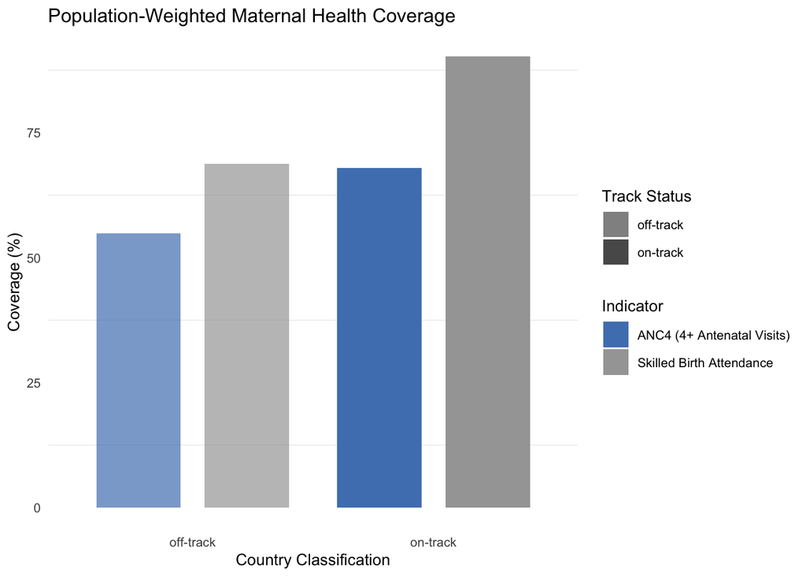

```r
weighted_df_long <- weighted_df %>%
  filter(track_status != "Difference (off - on)") %>%
  pivot_longer(cols = c(weighted_anc4, weighted_sba),
               names_to = "indicator",
               values_to = "coverage") %>%
  mutate(indicator = recode(indicator,
                            weighted_anc4 = "ANC4 (4+ Antenatal Visits)",
                            weighted_sba = "Skilled Birth Attendance"))

ggplot(weighted_df_long,
       aes(x = track_status,
           y = coverage,
           alpha = track_status,
           fill = indicator)) +
  geom_bar(stat = "identity",
           position = position_dodge(width = 0.9),
           width = 0.7) +
  labs(
    title = "Population-Weighted Maternal Health Coverage",
    x = "Country Classification",
    y = "Coverage (%)",
    fill = "Indicator",
    alpha = "Track Status"
  ) +
  scale_alpha_manual(
    values = c("on-track" = 1, "off-track" = 0.7)
  ) +
  scale_fill_manual(
    values = c(
    "ANC4 (4+ Antenatal Visits)" = "#4F81BD",  # blue
    "Skilled Birth Attendance"   = "#A5A5A5")   # grey
  ) +
  theme_minimal(base_size = 10) +
  theme (
    panel.grid.major = element_blank()
  )
```

## 4 Interpretation

The analysis reveals a notable disparity in maternal health coverage between on-track and off-track countries, based on two key indicators: 4+ antenatal care visits (ANC4) and skilled birth attendance (SBA).

These estimates are population-weighted using projected births in 2022, ensuring the results are representative of maternal health service access among women giving birth.

However, some caveats apply:

- Several countries lacked recent data for these indicators, and those missing values were excluded from the analysis. This may introduce estimation bias or under-representation in certain regions.
- Country classification is based exclusively on progress toward reducing under-five mortality (U5MR), which may not fully reflect the overall performance or capacity of national health systems.

### 4.1 Positions Applied

- Learning and Skills Data Analyst Consultant – Req. #581598
- Household Survey Data Analyst Consultant – Req. #581656
- Administrative Data Analyst – Req. #581696
- Microdata Harmonization Consultant – Req. #581699